# DS 202 Final Project

Isaac

December 14, 2018

Insert the dataset and any packages we will use.

# Data

Kickstarter is a crowdfunding website where you can offer rewards in exchange for donation pledges to reach a project funding goal. This dataset obtained from Kaggle contains data from over 350,000 Kickstarter projects in 2018

# Variables

Usd_pledged_real–Takes the amount donated towards a project and converts it into USD Usd_goal_real–Takes the amount a project hoped to raise and converts it into USD Category–Puts projects into very specific categories Main_category–Combines categories into larger groupings Backers–Accounts for the specific number of people who donated to a project State–Examines the state of the project

# Goal

We would like to explore this data to find what effects if a Kickstarter succeeds, looking at amount of time to pledge, the goal amount, and how it is effected by the category.

# Data Cleaning

```r
ks_data = ks_data %>% separate(launched, into=c("launch_date", "launch_time"), sep = " ")# %>% mutate(launch_date = ymd(launch_date), deadline = ymd(deadline), ID = as.factor(ID))
```

corrects the date/time variable Launched

# Data Exploration

## Country(Nic)

```r
summary(ks_data$country)
```

```
##     AT     AU     BE     CA     CH     DE     DK     ES     FR     GB
##    597   7839    617  14756    761   4171   1113   2276   2939  33672
##     HK     IE     IT     JP     LU     MX   N,0"     NL     NO     NZ
##    618    811   2878     40     62   1752   3797   2868    708   1447
##     SE     SG     US
##   1757    555 292627
```

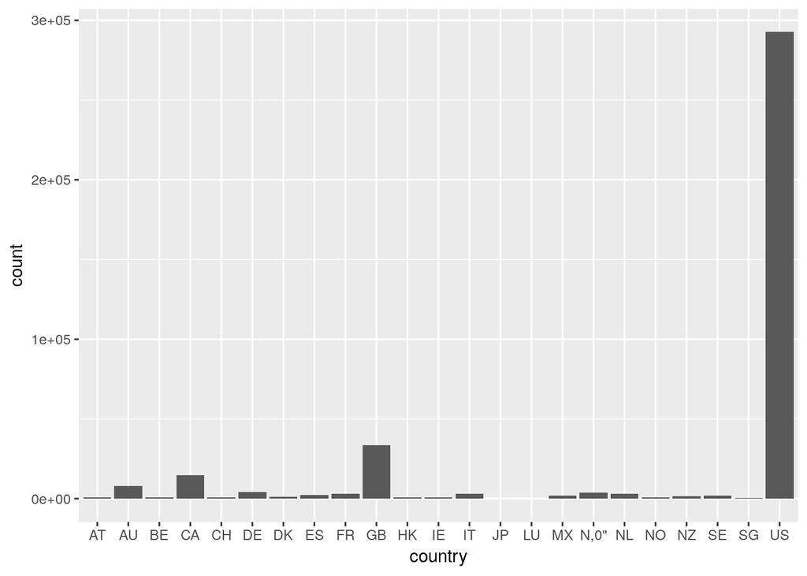

```r
ks_data %>% ggplot(aes(x=country))+geom_bar()
```

This shows us that the wide majority of the dataset is from the U.S.

## usd.goal.real(Nic)

```r
summary(ks_data$usd_goal_real)
```

```
##      Min.   1st Qu.    Median      Mean   3rd Qu.      Max.
##         0      2000      5500     45454     15500 166361391
```

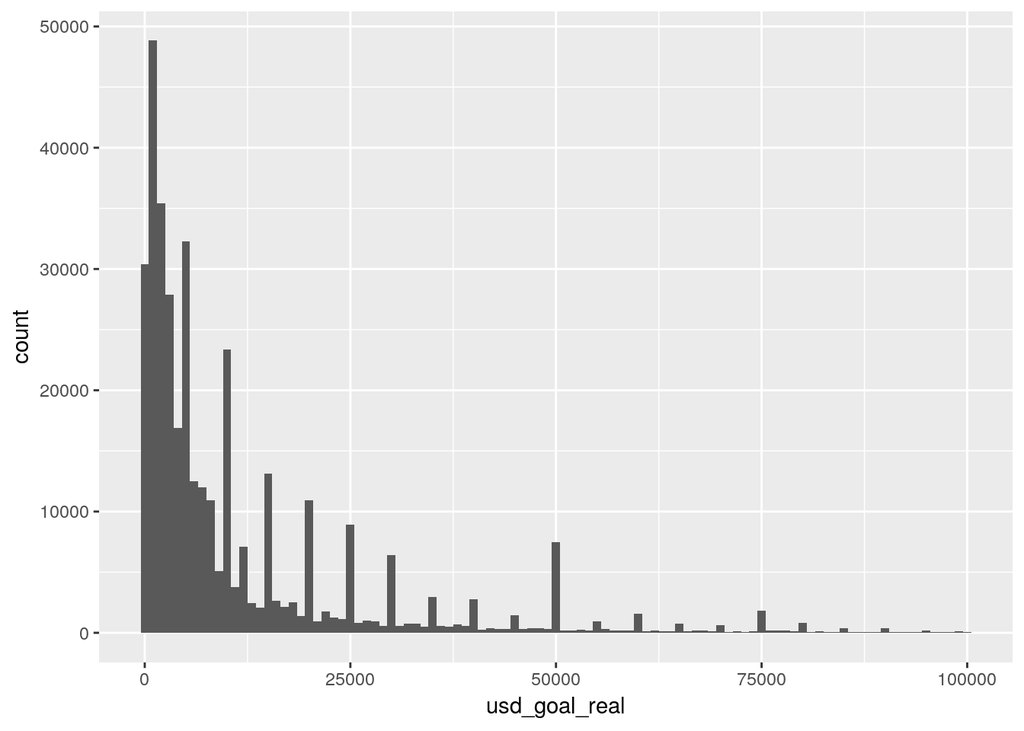

```r
ks_data %>% filter(usd_goal_real < 100000) %>% ggplot(aes(x=usd_goal_real))+geom_histogram(binwidth=1000)
```

This distribution shows us that the majority of people plan to raise between $2,000 and $15,500. The distribution is very skewed right, meaning an accurate measure of center would be the median, which is located at $5,500.

## usd.pledged.real(Nic)

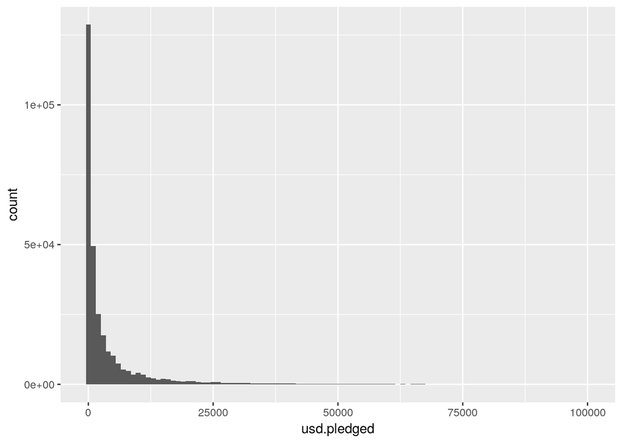

```r
ks_data %>% filter(usd.pledged <= 100000 & usd.pledged > 0) %>% ggplot(aes(x=usd.pledged))+geom_histogram(binwidth=1000)
```

This distibution is heavily skewed right, meaning the most accurate measure of center would be the median. The median for usd.pledged is $624.

## category(Isaac)

```r
summary(ks_data$category)
```

```
##   Product Design      Documentary            Music   Tabletop Games
##            22314            16139            15727            14180
##           Shorts      Video Games             Food     Film & Video
##            12357            11830            11493            10108
##          Fiction          Fashion       Nonfiction              Art
##             9169             8554             8318             8253
##          Apparel          Theater       Technology             Rock
##             7166             7057             6930             6758
## Children's Books             Apps       Publishing        Webseries
##             6756             6345             6018             5762
##      Photography       Indie Rock   Narrative Film              Web
##             5752             5657             5188             5153
##           Comics           Crafts   Country & Folk           Design
##             4996             4664             4451             4199
##          Hip-Hop         Hardware              Pop         Painting
##             3912             3663             3350             3294
##            Games     Illustration      Accessories       Public Art
##             3226             3175             3165             3077
##         Software          Gadgets      Restaurants      Mixed Media
##             3048             2965             2819             2757
##      Comic Books        Art Books  Classical Music        Animation
##             2743             2676             2613             2541
##    Playing Cards           Drinks            Dance           Comedy
##             2497             2422             2322             2320
##            Drama Electronic Music  Performance Art      World Music
##             2179             2170             2154             2102
##   Graphic Design   Graphic Novels             Jazz        Sculpture
##             2002             1864             1850             1810
##      Small Batch     Mobile Games      Food Trucks       Journalism
##             1808             1789             1752             1747
##       Photobooks            Plays           Poetry      Digital Art
##             1580             1378             1369             1346
##           Horror      Periodicals          Jewelry        Wearables
##             1287             1265             1239             1233
##              DIY      Woodworking            Farms           People
##             1173             1167             1154             1103
##            Faith       Live Games   Conceptual Art       Television
##             1092             1050             1030             1015
##     Performances         Footwear     Experimental Radio & Podcasts
##             1013              931              924              923
##         Academic          Musical  DIY Electronics    Ready-to-wear
##              916              913              902              864
##           Spaces        Festivals      Young Adult           Events
##              841              839              821              818
##      Anthologies         Fine Art     Architecture        Thrillers
##              784              776              760              746
##  Science Fiction           Action           Places            Print
##              744              740              739              727
##            Metal     Music Videos      3D Printing          (Other)
##              717              709              683            17244
```

[figure not shown]

```r
ks_data%>%ggplot(aes(category)) + geom_bar(aes()) + coord_flip()
```

## main category(Isaac)

```r
summary(ks_data$main_category)
```

```
##          Art       Comics       Crafts        Dance       Design
##        28153        10819         8809         3768        30070
##      Fashion Film & Video         Food        Games   Journalism
##        22816        63585        24602        35231         4755
##        Music  Photography   Publishing   Technology      Theater
##        51918        10779        39874        32569        10913
```

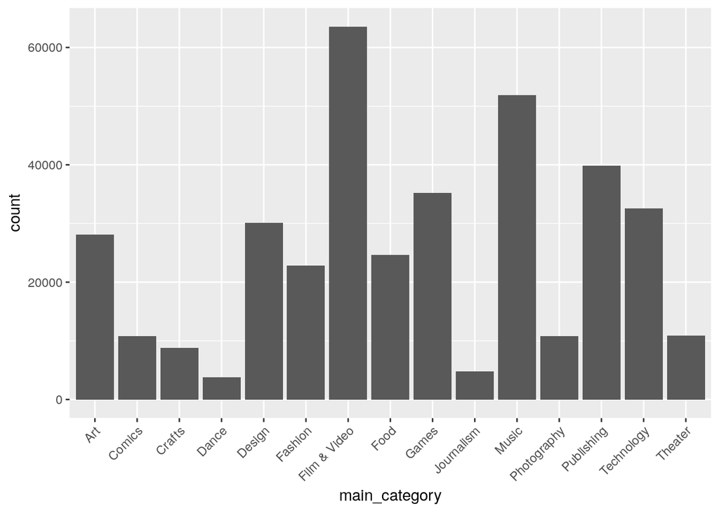

```r
ks_data%>%ggplot(aes(main_category)) + geom_bar(aes()) + theme(axis.text.x = element_text(angle=45,vjust=1, hjust=1))
```

The barchart shows that film & video and music are indeed the largest two categories, however there is much more fluctuation between the other categories than I expected. It makes sense that film and music are the two highest categories, as it is less time consuming to write and produce a song or film than coming up with something for another category. For example, for the majority of people it would most likely take less time to produce a new song than it would to think of a creative idea for a new restaurant and create a coordinating business plan. It is surprising to me that there are so few dance kickstarters, as dance and music seem to go hand-in-hand.

## currency(Isaac)

```r
summary(ks_data$currency)
```

```
##    AUD    CAD    CHF    DKK    EUR    GBP    HKD    JPY    MXN    NOK
##   7950  14962    768   1129  17405  34132    618     40   1752    722
##    NZD    SEK    SGD    USD
##   1475   1788    555 295365
```

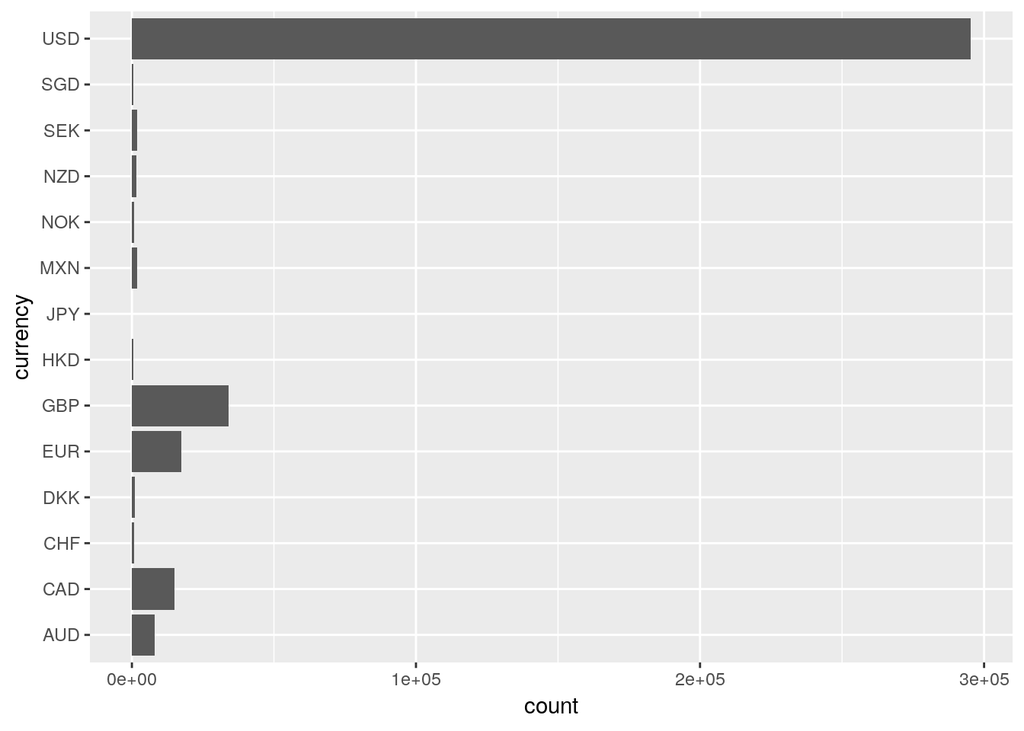

```r
ks_data%>%ggplot(aes(currency)) + geom_bar(aes()) + coord_flip()
```

This distribution is about what I expected, as most use USD, with the second most being the pound, and a respectable number using the euro, Canadian dollar, and the Australian dollar. Outside of those top 5 currencies, there are not a lot of kickstarters that use any other specific currency.

## backers(Dan)

```r
summary(ks_data$backers)
```

```
##     Min.  1st Qu.   Median     Mean  3rd Qu.     Max.
##      0.0      2.0     12.0    105.6     56.0 219382.0
```

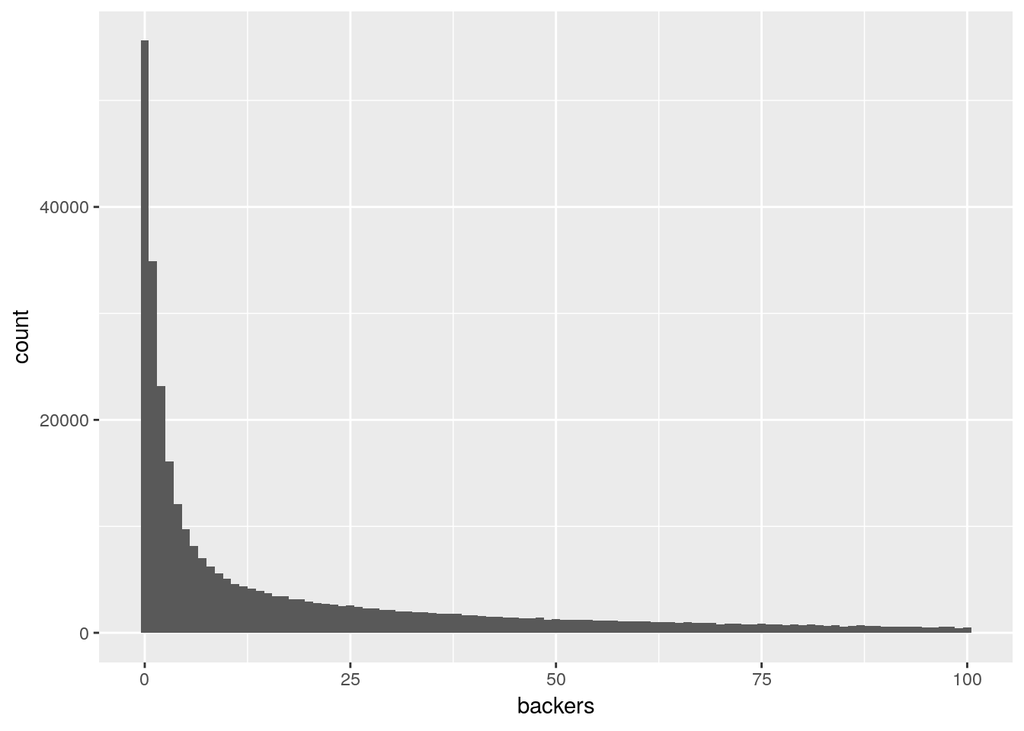

```r
ks_data %>% filter(backers <=100, ) %>%
  ggplot(aes(x=backers))+geom_histogram(binwidth=1)
```

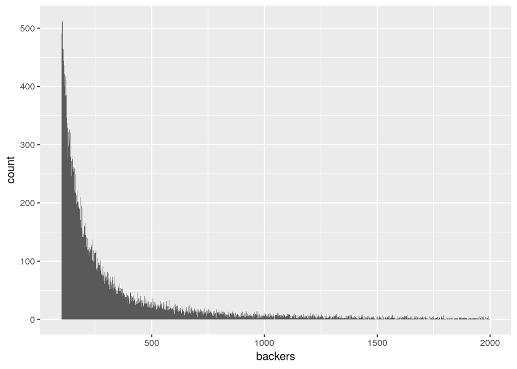

```r
ks_data %>% filter(backers >100, backers<2000) %>%
  ggplot(aes(x=backers))+geom_histogram(binwidth=1)
```

There is a very large range as you can see in the summary. I would be interested to see a summary ommiting projects with no backers. The majority of backers seem to be between zero and 100 but they go well over 200,000.

## State(Dan)

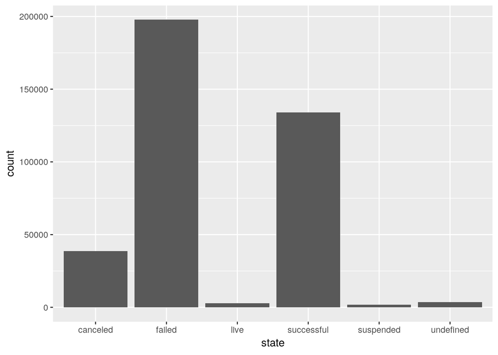

```r
ks_data %>% ggplot(aes(x=state))+geom_bar()
```

Most projects failed and a large portion were canceled but more projects succeeded than I expected.

### Two-Variable Data Exploration

## Pledge per backer vs goal by category(Dan)

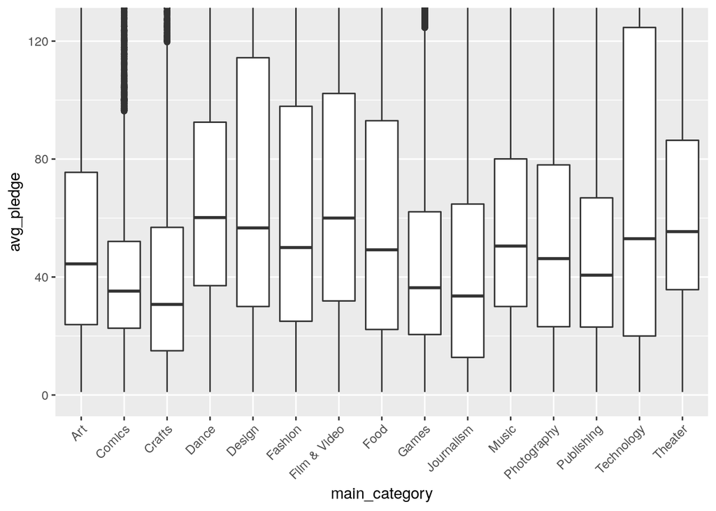

```r
avg_pledge<-ks_data$pledged/ks_data$backers


ks_data %>% ggplot(aes(y=avg_pledge, x=main_category))+geom_boxplot()+theme(axis.text.x = element_text(angle=45,vjust=1, hjust=1))+ coord_cartesian(ylim=c(-1,125))
```

## State by country(Dan)

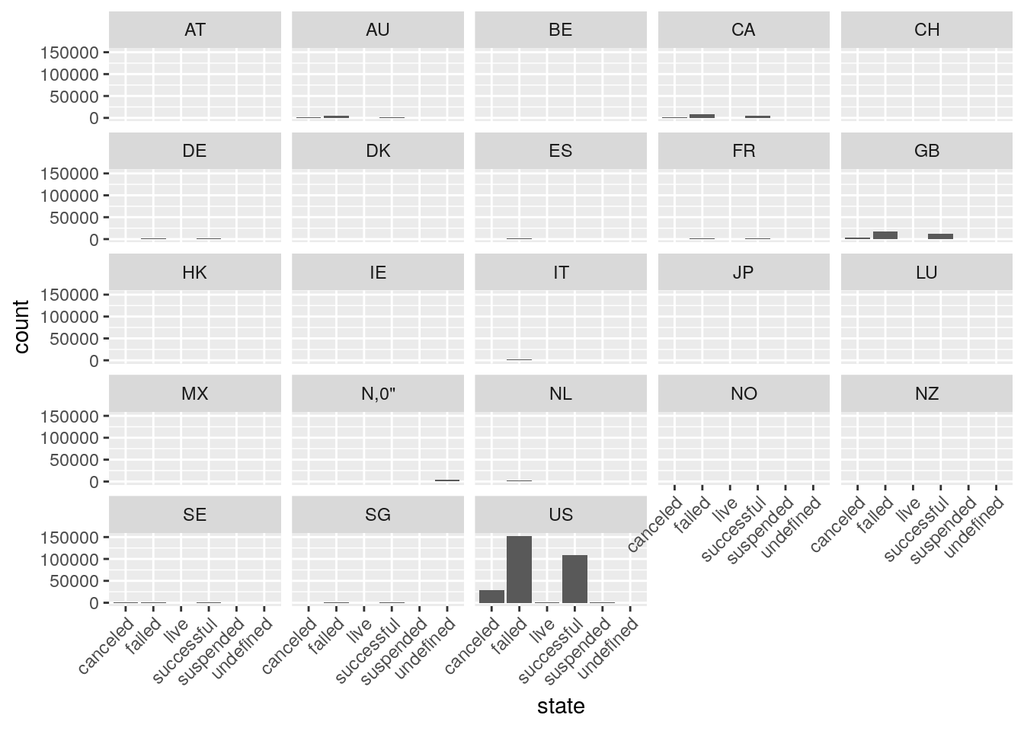

Most of our data is from the US but I was curious to see if we could gather any information about differences across countries when it comes to success or failure of a project. As we can see in the graphs above, the data is disproportionally from the US so it’s hard to gather much.

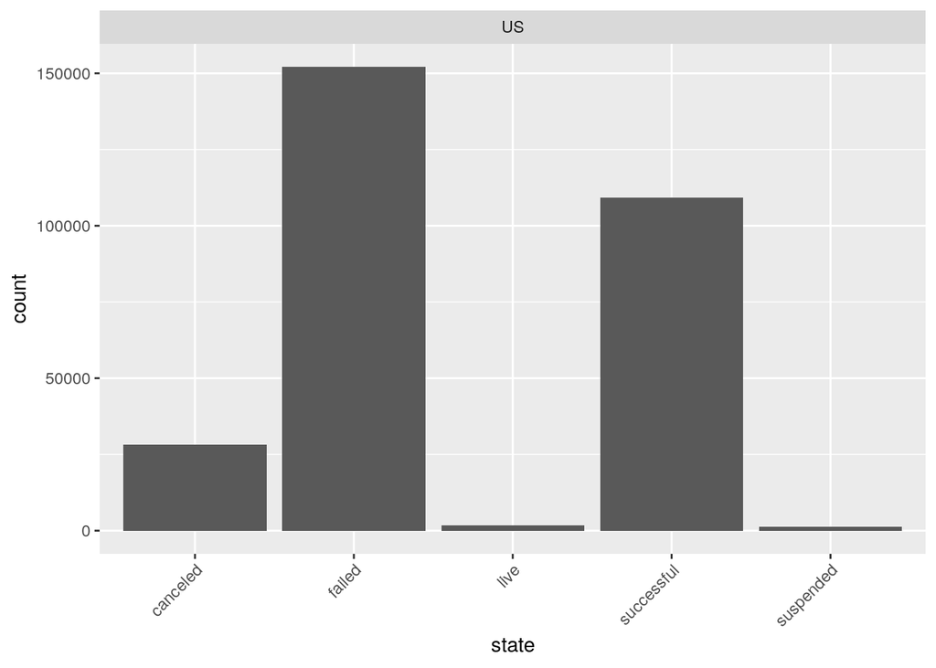

```r
ks_data %>% filter (country=="US") %>% ggplot(aes(x=state))+geom_bar()+facet_wrap(country~.)+theme(axis.text.x = element_text(angle=45,vjust=1, hjust=1))
```

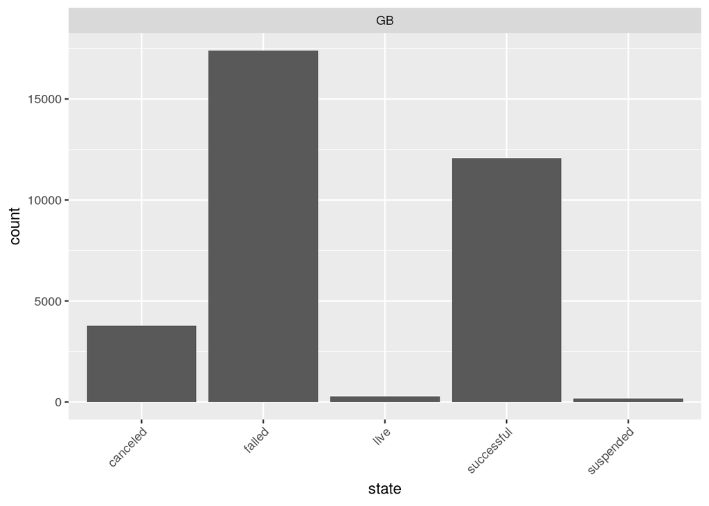

```r
ks_data %>% filter (country=="GB") %>% ggplot(aes(x=state))+geom_bar()+facet_wrap(country~.)+theme(axis.text.x = element_text(angle=45,vjust=1, hjust=1))
```

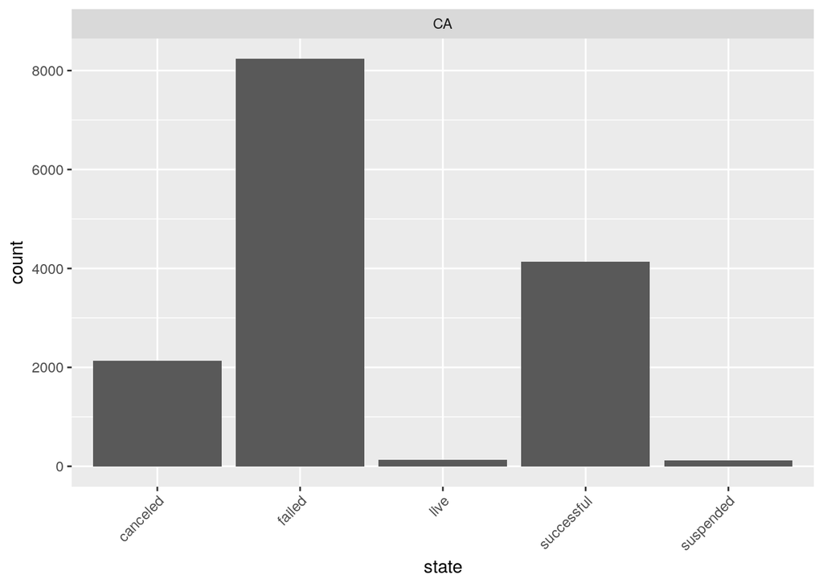

```r
ks_data %>% filter (country=="CA") %>% ggplot(aes(x=state))+geom_bar()+facet_wrap(country~.)+theme(axis.text.x = element_text(angle=45,vjust=1, hjust=1))
```

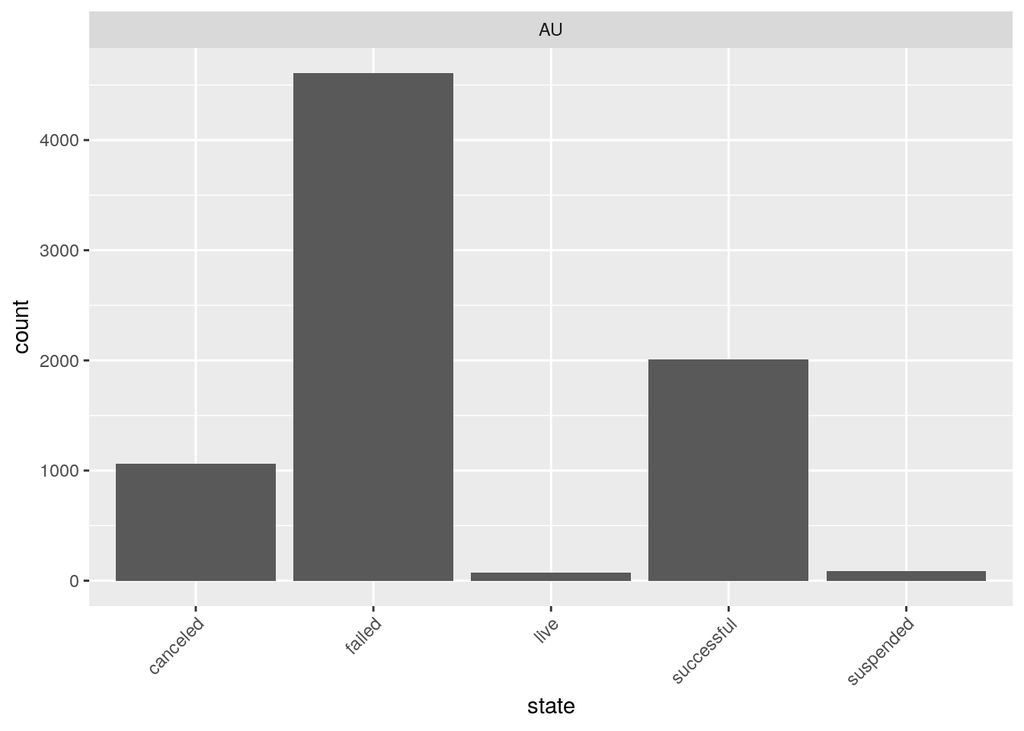

```r
ks_data %>% filter (country=="AU") %>% ggplot(aes(x=state))+geom_bar()+facet_wrap(country~.)+theme(axis.text.x = element_text(angle=45,vjust=1, hjust=1))
```

## Goal vs Success by category(Nic)

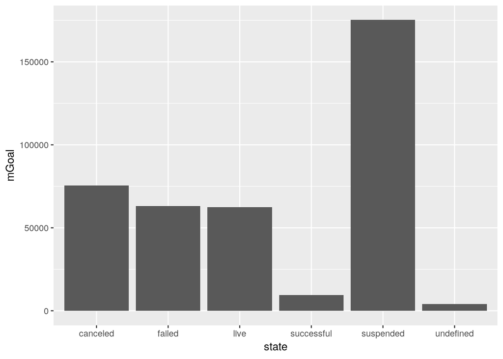

```r
ks_data %>% group_by(state) %>% summarize(mGoal = mean(usd_goal_real)) %>% ggplot(aes(x=state, y=mGoal))+geom_bar(stat="identity")
```

It appears that cancelled, failed, and currently running kickstarters are roughly equal. Successful kickstarters are very low. I assume this is due to a lot of low goal projects being funded. The mean goal of suspened projects, ones that broke the rules or were scams, is very high.

```r
spread(ks_data, key=state, value = usd_goal_real) %>% select(c(canceled, failed, live, successful, suspended, undefined)) %>% summary()
```

```
##     canceled             failed               live
##  Min.   :        0   Min.   :        0   Min.   :       1
##  1st Qu.:     3290   1st Qu.:     2500   1st Qu.:    2053
##  Median :    10000   Median :     7500   Median :    6547
##  Mean   :    75579   Mean   :    63175   Mean   :   62535
##  3rd Qu.:    30000   3rd Qu.:    20000   3rd Qu.:   18505
##  Max.   :100000000   Max.   :166361391   Max.   :99000000
##  NA's   :339882      NA's   :180942      NA's   :375862
##    successful        suspended           undefined
##  Min.   :      0   Min.   :        1   Min.   :   85.3
##  1st Qu.:   1302   1st Qu.:     1000   1st Qu.: 2238.6
##  Median :   3838   Median :     5000   Median : 3530.4
##  Mean   :   9533   Mean   :   175208   Mean   : 4103.0
##  3rd Qu.:  10000   3rd Qu.:    20000   3rd Qu.: 5038.2
##  Max.   :2015609   Max.   :100000000   Max.   :77357.5
##  NA's   :244705    NA's   :376815      NA's   :375099
```

It seems to have a successful kickstarter, keep it around 10,000, no more than 2,000,000

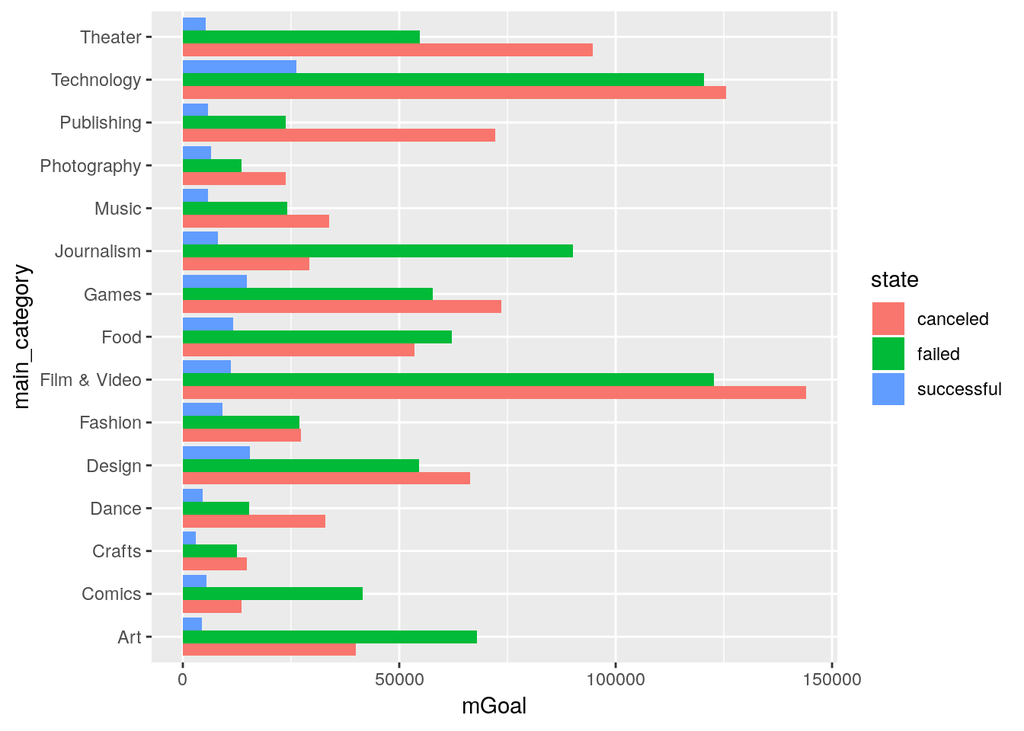

```r
ks_data %>% filter(state %in% c('canceled', 'failed', 'successful')) %>% group_by(state, main_category) %>% summarise(mGoal=mean(usd_goal_real)) %>%  ggplot(aes(x=main_category, y=mGoal, fill=state))+geom_bar(stat="identity", position='dodge')+coord_flip()
```

## Time elapsed vs success by category(Nic)

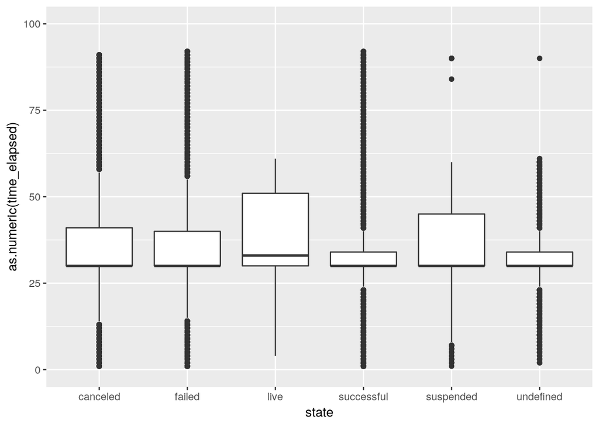

```r
ks_data %>% mutate(time_elapsed = ymd(deadline)-ymd(launch_date)) %>% ggplot(aes(x=state, y=as.numeric(time_elapsed)))+geom_boxplot()+ ylim(0,100)
```

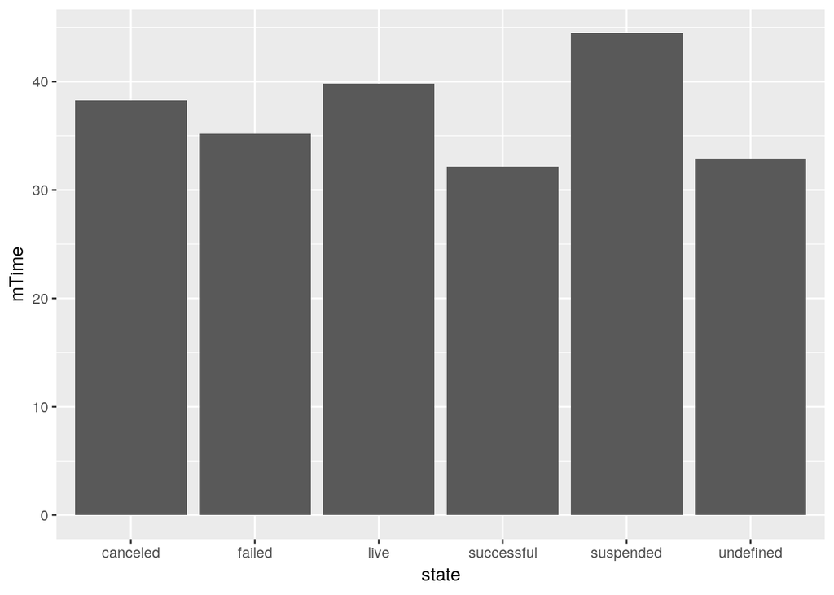

```r
ks_data %>% mutate(time_elapsed = ymd(deadline)-ymd(launch_date)) %>% group_by(state) %>% summarize(mTime = mean(as.numeric(time_elapsed))) %>% ggplot(aes(x=state, y=mTime))+geom_bar(stat="identity")
```

Successful kickstarters have slightly shorter deadlines on average, but there does not seem to be enough of a difference to actually be significant.

## Goal vs pledged by category(Isaac)

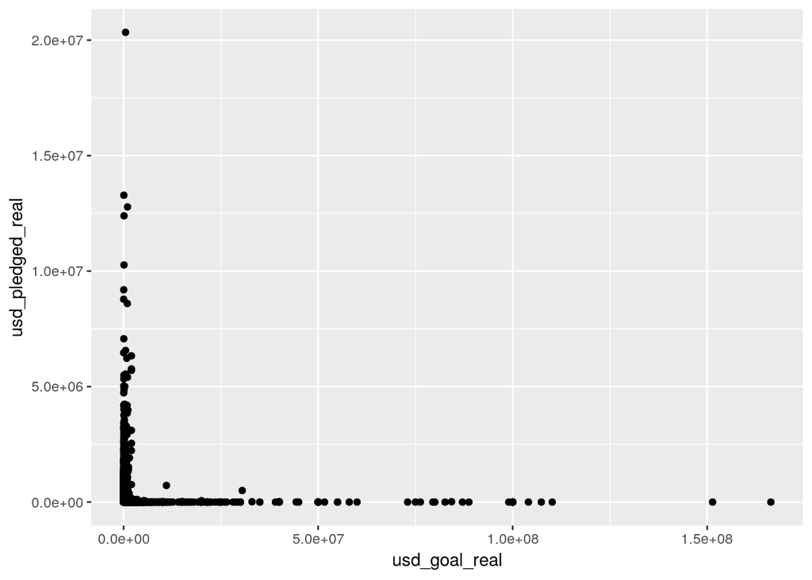

```r
ggplot(aes(x = usd_goal_real, y = usd_pledged_real), data=ks_data) + geom_point()
```

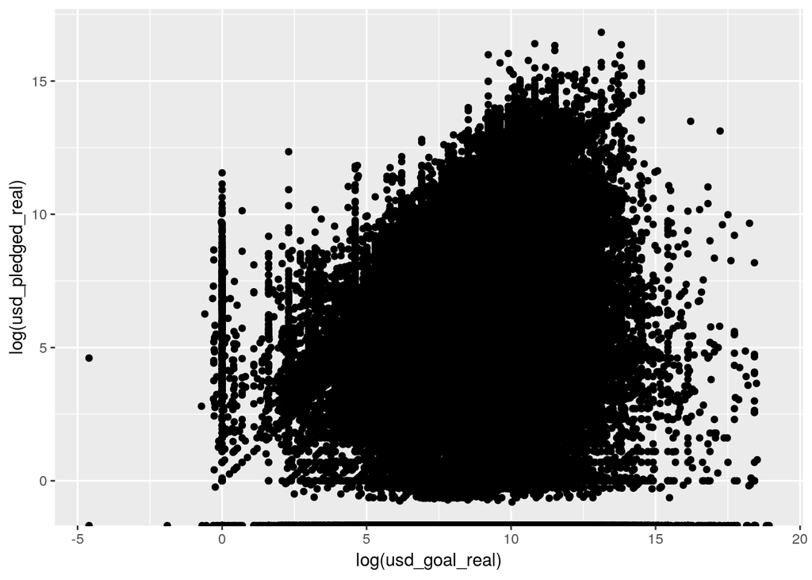

```r
ggplot(aes(x = log(usd_goal_real), y = log(usd_pledged_real)), data=ks_data) + geom_point()
```

The initial graph of goal vs pledged is very jumbled and hard to read. After performing a log transformation on each variable, the graph is a little easier to read. There does not appear to be an obvious shape in the graph. We can tell it is positive, but there is not much of a form to the graph and it is stil hard to determine much of a relationhsip between the two.

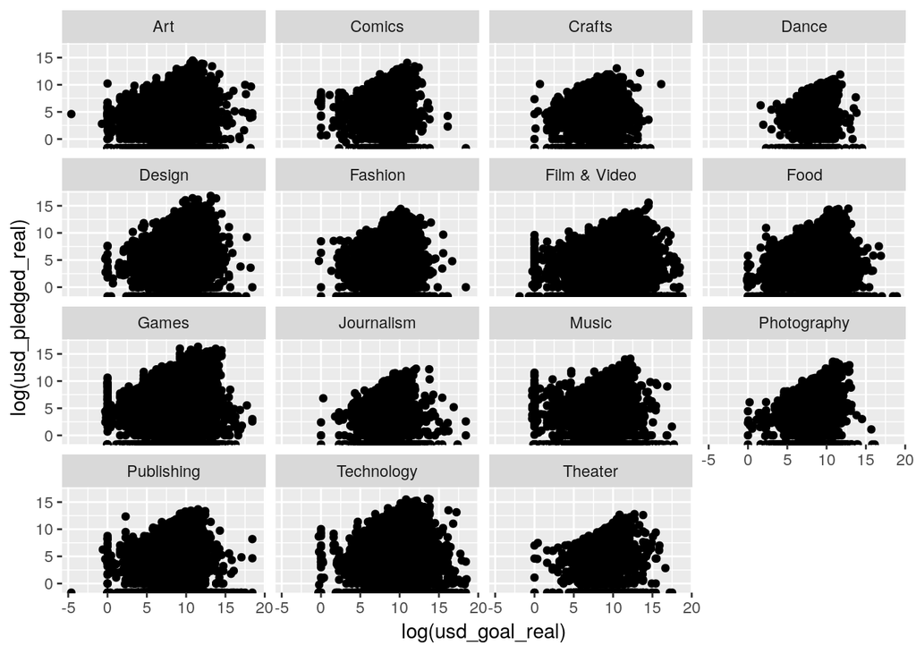

```r
ggplot(aes(x = log(usd_goal_real), y = log(usd_pledged_real)), data=ks_data) + geom_point() + facet_wrap(~ks_data$main_category)
```

When we separate this graph into each different category, it is easier to see a relationship in some places. Photography looks to have the strongest relationship. Theater, outside of a few outliers looks to have a somewhat noticeable relationship, along with Food. However, none of these look to be significant. The relationship between goal amount and amount pledged does not look to be beneficial to us. This makes some sense, especially since so many kickstarters were failed or cancelled.